# Capital One Data Challenge

Declan Murphy

2025-09-13

# Data Challenge – Flights

The scripts below documents the calculations, transformations, and analysis performed responsive to the Capital One Data Challenge. Specifically, this challenge uses real-world flight data to generate insights.

Required packages for this script are **tidyverse**, **readxl**, and **knitr**; the import functions and output are suppressed for improved readability.

First, I will read in the source data. All file paths are relative to the project folder (or cloned repository, if using GitHub). The “strip.white” function removes white spaces during import.

```r
# All file paths are relative to the working directory

Flights <- read.csv('./data/Flights.csv', strip.white = TRUE)
Tickets <- read.csv('./data/Tickets.csv', strip.white = TRUE)
Airport_Codes <- read.csv("./data/Airport_Codes.csv", strip.white = TRUE)

Metadata <- read_xlsx('./data/Airline_Challenge_Metadata.xlsx')
```

Then I will clean the data. In doing so, I noted the following data quality issues:

- Null values in Airport_Codes data for IATA_CODE
- White space in text fields (addressed above during import)
- Numbers stored as strings – DISTANCE in the Flights dataset
- Numbers stored as strings – AIR_TIME in the Flights dataset

Per the assignment instructions, I filter to remove cancelled flights (CANCELLED == 1) and tickets that are *not* round-trip (ROUNDTRIP == 0).

To join the Airport information to the Ticket data, I left join the Airport Code on the Ticket data using the IATA Code, first on the Origin airport and then the destination airport, and then select the necessary columns from the result.

In addition to cleaning the data, I create “Normalized” Delay columns, which only tally the minutes beyond 15 minutes (i.e. where the delay penalty kicks in) and ignore early arrivals (i.e. where Delay < 0).

```r
Flights <- Flights %>%
  filter(CANCELLED == 0.00) %>%
  mutate(DISTANCE = suppressWarnings(as.numeric(DISTANCE)),
         AIR_TIME = suppressWarnings(as.numeric(AIR_TIME))) %>%
  mutate(Normalized_Dep_Delay = if_else(DEP_DELAY > 15,
                                        DEP_DELAY - 15,
                                        0),
         Normalized_Arr_Delay = if_else(ARR_DELAY > 15,
                                        ARR_DELAY - 15,
                                        0))

Airport_Codes <- Airport_Codes %>%
  filter(TYPE == "medium_airport" | TYPE == "large_airport") %>% # Filter to medium and large airports
  filter(IATA_CODE %in% unique(IATA_CODE) & !is.na(IATA_CODE))

Tickets <- Tickets %>%
  filter(ROUNDTRIP == 1) %>% # Filter to only round trip tickets
  mutate(ITIN_FARE = replace_na(as.numeric(ITIN_FARE), 0))

Tickets_with_Airport <- left_join(Tickets,
                                  Airport_Codes,
                                  by = c("ORIGIN" = "IATA_CODE"))

Tickets_with_Airport <- left_join(Tickets_with_Airport,
                                  Airport_Codes,
                                  by = c("DESTINATION" = "IATA_CODE"))

Tickets_with_Airport <- Tickets_with_Airport %>%
  select(1:12,
         Origin_Airport_Type = TYPE.x,
         Destination_Airport_Type = TYPE.y)
```

Finally, per the instructions, I will record the values assumed for per-mile and fixed costs, to reference later in the analysis.

```r
# Per the instructions, we can assume the following (scalar) values for use later one:
Fuel_Oil_Maint_Crew_per_Mile <- 8.00
Depreciation_Insurance_Other_per_Mile <- 1.18
Per_Mile_Costs <- Fuel_Oil_Maint_Crew_per_Mile + Depreciation_Insurance_Other_per_Mile
Medium_Airport_Cost <- 5000
Large_Airport_Cost <- 10000
Max_Occupancy <- 200 # Max occupancy of each airplane
Upfront_Cost <- 90000000 # Upfront cost of each airplane
```

## TASK 1

For the first task, I want to determine *what are the ten busiest round trip routes*?

To aggregate to round trip routes, I first create a unique “Route” key using pmin() and pmax(). Pmin() and pmax() return the parallel minimum and maximum (respecitvely) for the input values. This ensures that routes are correctly grouped, such that Origin A and Destination B are paired with Origin B and Destination A, e.g.

Having done so, I create the Airport_Cost field using a case_when() statement based on the origin and destination airports.

Once that data is arranged, I can group by the route and create summary metrics. Specifically, I sum the passengers field from the Tickets dataset, as well as the total of all fares, and take the mean value of the airport cost calculated above (for later use).

```r
Tickets_with_Airport <- Tickets_with_Airport %>%
  mutate(Route = paste0(pmin(ORIGIN, DESTINATION),
                        pmax(ORIGIN, DESTINATION))) %>%
  mutate(Airport_Cost = case_when(
    Origin_Airport_Type == "medium_airport" & Destination_Airport_Type == "medium_airport" ~ 10000,
    Origin_Airport_Type == "medium_airport" & Destination_Airport_Type == "large_airport" ~ 15000,
    Origin_Airport_Type == "large_airport" & Destination_Airport_Type == "medium_airport" ~ 15000,
    Origin_Airport_Type == "large_airport" & Destination_Airport_Type == "large_airport" ~ 20000,
    .default = 0
  ))

# Use of pmin() and pmax() allows for pairing of routes with Origin A -> Dest B
# and Origin B -> Dest A

Round_Trips_Summary <- Tickets_with_Airport %>%
  group_by(Route) %>%
  summarize(total_passengers = sum(PASSENGERS, na.rm = TRUE),
            total_fares = sum(ITIN_FARE, na.rm = TRUE),
            route_airport_cost = mean(Airport_Cost)) %>%
  arrange(desc(total_passengers))
```

Now I will merge in the flight data. Analogous to the above, I first create the “Route” key using pmin() and pmax(), then group by Route and create summary metrics for the route.

Finally, I can left join the Round_Trip_Summary dataframe to the Flight_Summary data to have all necessary metrics.

```r
Flights_Summary <- Flights %>%
  mutate(Route = paste0(pmin(ORIGIN, DESTINATION),
                        pmax(ORIGIN, DESTINATION))) %>%
  group_by(Route) %>%
  summarize(total_dep_delay = sum(Normalized_Dep_Delay, na.rm = TRUE),
            total_arr_delay = sum(Normalized_Arr_Delay, na.rm = TRUE),
            total_air_time = sum(AIR_TIME, na.rm = TRUE),
            route_distance = median(DISTANCE, na.rm = TRUE),
            route_occupancy_rate = round(sum(OCCUPANCY_RATE) / n(), 4),
            total_flights_route = n())

# Merge flight data with ticket data

Round_Trips_Summary_Expanded <- left_join(Round_Trips_Summary,
                                          Flights_Summary,
                                          by = "Route")
```

```r
Busiest_Round_Trips <- Round_Trips_Summary_Expanded %>%
  ungroup() %>%
  slice_max(n=10, order_by = total_passengers)

kable(Busiest_Round_Trips$Route, col.names = "Busiest Routes")
```

| Busiest Routes |
| --- |
| JFKLAX |
| LGAORD |
| LAXSFO |
| EWRMCO |
| DENPHX |
| LAXORD |
| MCOPHL |
| LAXSEA |
| DTWMCO |
| ATLLGA |

## TASK 2

For the second task, I need to find the routes with are the most *profitable*. To do so, I want to find the total costs on each route, the total revenue, and naturally subtract costs from revenue to find profit.

As a reminder, the total costs consist of: - Fuel, Oil, Maintenance, and Crew: $8:00 per mile - Depreciation, Insurance, and Other: $1.18 per mile - Delay Costs: $75 per minute for each minute after 15 minutes of delay - Airport Costs: a fixed fee depending on airport size at the origin and destination.

For per-mile costs, I take the sum of the two per-mile factors ($9.18) and multiply that by the route distance and number of flights. For example, a route with a distance of 200 miles that provided 500 flights would have a total per-mile cost of 200 * 500 * $9.18 = $918,000 dollars.

In a previous steps, I already normalized the delay fields to only return the minutes greater than 15, and these have been aggregated to the total minutes of delay (above 15) for departure and arrival. Thus, I can simply take these and multiply them by 75 per-minute cost, and sum the departure and arrival costs.

In earlier steps, I already created the Airport Cost field for each route, so I just multiply this cost by the number of flights.

Summing all the cost values gives us the total cost for the route.

```r
Round_Trips_Summary_Expanded <- Round_Trips_Summary_Expanded %>%
  mutate(Route_Per_Mile_Costs = Per_Mile_Costs * route_distance * total_flights_route) %>%
  mutate(Delay_Costs = (total_dep_delay * 75) + (total_arr_delay * 75)) %>%
  mutate(Total_Airport_Cost = (route_airport_cost * total_flights_route)) %>%
  mutate(TOTAL_COSTS = Route_Per_Mile_Costs + Delay_Costs + Total_Airport_Cost)
```

Similarly, I create revenue using the given parameters. The components of revenue are: - Fares - Baggage: $70 per passenger (roundtrip) for an expected 50% of passengers

Total fares have been created in a prior step using the ticket dataset.

Baggage revenue can be found by first taking the estimated occupancy, which is the product of the occupancy rate and 200 (the assumed max occupancy). The resulting number of passengers can be halved and multiplied by 70 to get the baggage fare per flight, and multiplied by the total flights to get overall baggage revenue.

Finally, I sum fare revenue and baggage to get total revenue.

```r
Round_Trips_Summary_Expanded <- Round_Trips_Summary_Expanded %>%
  mutate(Occupancy = (Max_Occupancy * route_occupancy_rate),
         Baggage_Revenue = (0.5 * Occupancy * 70 * total_flights_route)) %>%
  mutate(TOTAL_REVENUE = total_fares + Baggage_Revenue)
```

Profit, then, is just the difference between the total revenue calculated above and the total costs calculated above for each route.

```r
Round_Trips_Summary_Expanded <- Round_Trips_Summary_Expanded %>%
  mutate(Profit = (TOTAL_REVENUE - TOTAL_COSTS)) %>%
  arrange(desc(Profit))
```

I then sort by profit and take the 10 routes with the highest profit.

```r
Most_Profitable_Routes <- Round_Trips_Summary_Expanded %>%
  ungroup() %>%
  slice_max(Profit, n = 10)

kable(Most_Profitable_Routes$Route, col.names = "Most Profitable Routes")
```

| Most Profitable Routes |
| --- |
| DENPUB |
| CLTHHH |
| ATWORD |
| MKGORD |
| DENGUC |
| ATWMSP |
| DENDRO |
| DROPHX |
| IADSHD |
| DENHDN |

This information is already represented here in a bar graph (below), arranged by greatest total revenue.

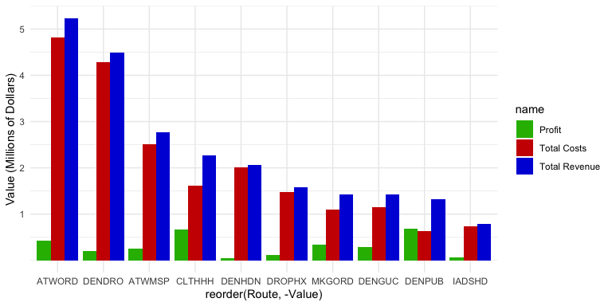

```r
Most_Profitable_Routes_bar <- pivot_longer(Most_Profitable_Routes,
                                           cols = c("TOTAL_COSTS",
                                                    "TOTAL_REVENUE",
                                                    "Profit"),
                                           values_to = "Value")

Graph1 <- ggplot(Most_Profitable_Routes_bar) +
  geom_bar(aes(fill = name,
               y = Value,
               x = reorder(Route, -Value)),
           position = "dodge",
           stat = "identity") +
  scale_y_continuous(name = "Value (Millions of Dollars)",
  breaks = c(1000000, 2000000, 3000000, 4000000, 5000000),
  labels = c(1, 2, 3, 4, 5)) +
  scale_fill_manual(values = c("#26B800", "#CC0000", "#001ED9"),
                    labels = c("Profit", "Total Costs", "Total Revenue")) +
  theme_minimal()

Graph1
```

## TASK 3

In recommending routes to invest in, I consider the following criteria: 1. Which routes are profitable? 2. Which routes have high occupancy already – and therefore could likely support a new service offering?

The latter is the key component for me – a route must be sufficiently busy that there will still be customer demand when a new service is offered. If a route is (currently) profitable with less than 50% mean occupancy, it is unlikely to still be profitable with even more sparsely populated flights.

Thus, for this exercise, I filter to flights with Occupancy over 50% (100 passengers), and *subsequently* filter those to profitable flights. Finally, I take the top 5 of these options sorted by profit.

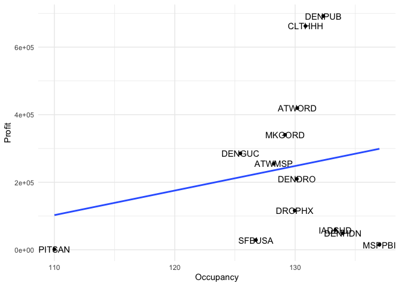

```r
Profitable_Routes <- Round_Trips_Summary_Expanded %>%
  filter(Profit > 0)

Occupancy_vs_Profit <- ggplot(Profitable_Routes,
                              aes(x = Occupancy, y = Profit)) +
  geom_point() +
  geom_smooth(method = "lm", se = FALSE) +
  geom_text(aes(label = Route),
            nudge_y = 0.5) +
  theme_minimal()

Occupancy_vs_Profit
```

```r
High_Occupancy <- Round_Trips_Summary_Expanded %>%
  filter(Occupancy > 100)

Profitable_Routes <- Profitable_Routes %>%
  filter(Route %in% High_Occupancy$Route) %>%
  slice_max(Profit, n = 5)

Chosen_Routes <- Profitable_Routes$Route

print(Chosen_Routes)
```

```
## [1] "DENPUB" "CLTHHH" "ATWORD" "MKGORD" "DENGUC"
```

## TASK 4

Given the choice of routes above, how many flights will it take for each one to break even?

To reiterate, the upfront cost of each airplane is $90,000,000.

A bar graph showing this information for each flight is also included.

```r
Upfront_Cost
```

```
## [1] 9e+07
```

```r
Chosen_Routes_Info <- Round_Trips_Summary_Expanded %>%
  filter(Route %in% Chosen_Routes) %>%
  ungroup() %>%
  mutate(Per_Trip_Profit = Profit / total_flights_route) %>%
  mutate(Trips_to_Profit = round(Upfront_Cost / Per_Trip_Profit, 0))

Chosen_Routes_Summary_Table <- Chosen_Routes_Info %>%
  select(Route, Trips_to_Profit)

kable(Chosen_Routes_Summary_Table)
```

| Route | Trips_to_Profit |
| --- | --- |
| DENPUB | 37191 |
| CLTHHH | 67115 |
| ATWORD | 246511 |
| MKGORD | 83546 |
| DENGUC | 102445 |

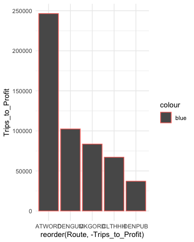

```r
Chosen_Routes_Bar <- ggplot(Chosen_Routes_Info) +
  geom_col(aes(x = reorder(Route, -Trips_to_Profit),
               y = Trips_to_Profit,
               color = "blue")) +
  theme_minimal()

Chosen_Routes_Bar
```

## TASK 5

The following are proposed KPI’s to monitor for these routes once implemented:

1. **On-Time Percentage** – What percentage of flights are on-time (i.e. no delays)? Once implemented, this can also be used to identify causal factors influencing delays.
2. **Average Delay** – Related to the above: when delays occur, how long are they? Monitoring and reducing delays will reduce the associated costs.
3. **Occupancy Rate** – How full are these flights? How can they be better scheduled and/or priced to maximize occupancy?
4. **Average Ticket Price** – What prices are consumers paying for these routes? Are these trending upward or downward? Can we identify seasonality or other notable patterns?
5. **Percent of Flights Cancelled** – What percentage of flights are fully cancelled? What are the underlying factors and how can we address those?

## Conclusion and Next Steps

To reiterate, I recommended investing in these five routes:

```r
Route_Names_Clean <- paste(substr(Chosen_Routes_Info$Route, 1, 3),
                           " round trip to ",
                           substr(Chosen_Routes_Info$Route, 4, 6))

kable(Route_Names_Clean, col.names = "Routes")
```

| Routes |
| --- |
| DEN round trip to PUB |
| CLT round trip to HHH |
| ATW round trip to ORD |
| MKG round trip to ORD |
| DEN round trip to GUC |

Using the metrics in Task 5, I will monitor these routes to ensure high performance and address issues as they arise.

With additional time, it would be ideal to have data on: - Customer satisfaction with existing service / airlines - Potential for dynamic pricing of baggage, and more flexible assumptions about charges for baggage fees - Additional quarters of flight and ticket data, to see if these patterns hold for an entire fiscal year, e.g.

Overall, though, these is value in the data in hand and its ability to inform decision making. This initial analysis, while by no means comprehensive, demonstrates how I can leverage real world data sets to generate actionable insights.